# R Workshop: Exploratory Data Analysis

2024-05

# Introduction

In this part of the workshop, we are going to use R language to analyze, filter, group, and plot data.

## Loading packages

First, we have to install packages (if not already installed). The packages we are going to use are tidyverse, ggplot2, dplyr, and magrittr.

tidyverse: This is a collection of R packages designed for data science. It includes some datasets too.

ggplot2: This package is used for creating elegant and complex data visualizations.

dplyr: This package provides a set of functions for data manipulation tasks such as filtering, grouping, summarizing, and mutating data frames.

magrittr: This package provides the pipe operator %>%, which allows you to chain together multiple operations.

To install a package, use install.packages(“name of package”) in the console or terminal below. You only have to do this once.

```r
options(repos = c(CRAN = "https://cran.r-project.org"))

install.packages("tidyverse")
```

```r
install.packages("ggplot2")
install.packages("dplyr")
install.packages("magrittr")
```

To run a cell, click on the run button.

After installing the packages, we should include or import them to use them later:

```r
library(tidyverse)
```

```r
library(ggplot2)
library(dplyr)
library(magrittr)
```

## Loading data and initial exploring dataset

The packages we are using have many good datasets inside them. We can use them too. To see their available datasets, run the following chunk:

```r
data(package = "ggplot2")
```

We can also load data from a csv file and use it. We are going to use Bachelor_Degrees_Majors.csv dataset which consists of information about number of college students in the US for different states.

```r
# View the first few rows of the dataset
data <- read.csv("Bachelor_Degrees_Majors.csv")
```

```r
# View the first few rows of the dataset
head(data)
```

```
##     State   Sex    Age.Group Bachelor.s.Degree.Holders Science.and.Engineering
## 1 Alabama Total 25 and older                   885,357                 263,555
## 2 Alabama Total     25 to 39                   268,924                  90,736
## 3 Alabama Total     40 to 64                   418,480                 115,762
## 4 Alabama Total 65 and older                   197,953                  57,057
## 5 Alabama  Male 25 and older                   405,618                 159,366
## 6 Alabama  Male     25 to 39                   117,794                  50,188
##   Science.and.Engineering.Related.Fields Business Education
## 1                                 98,445  210,147   141,071
## 2                                 32,378   58,515    29,342
## 3                                 46,724  112,271    63,875
## 4                                 19,343   39,361    47,854
## 5                                 26,004  113,909    29,490
## 6                                  7,712   29,859     6,357
##   Arts..Humanities.and.Others
## 1                     172,139
## 2                      57,953
## 3                      79,848
## 4                      34,338
## 5                      76,849
## 6                      23,678
```

```r
str(data)
```

```
## 'data.frame':    612 obs. of  9 variables:
##  $ State                                 : chr  "Alabama" "Alabama" "Alabama" "Alabama" ...
##  $ Sex                                   : chr  "Total" "Total" "Total" "Total" ...
##  $ Age.Group                             : chr  "25 and older" "25 to 39" "40 to 64" "65 and older" ...
##  $ Bachelor.s.Degree.Holders             : chr  "885,357" "268,924" "418,480" "197,953" ...
##  $ Science.and.Engineering               : chr  "263,555" "90,736" "115,762" "57,057" ...
##  $ Science.and.Engineering.Related.Fields: chr  "98,445" "32,378" "46,724" "19,343" ...
##  $ Business                              : chr  "210,147" "58,515" "112,271" "39,361" ...
##  $ Education                             : chr  "141,071" "29,342" "63,875" "47,854" ...
##  $ Arts..Humanities.and.Others           : chr  "172,139" "57,953" "79,848" "34,338" ...
```

```r
# Ensure column names match exactly
numeric_cols <- c("Bachelor.s.Degree.Holders", "Science.and.Engineering", "Science.and.Engineering.Related.Fields", "Business", "Education", "Arts..Humanities.and.Others")
data[, numeric_cols] <- lapply(data[, numeric_cols], function(x) as.numeric(gsub(",", "", x)))
# 885,357 => 885357
```

Total is redundant so we should remove rows with Sex=Total.

```r
# in dataset, we have male, female, and total (which is sum of male and female). SO, rows with Sex == "Total" are redudant. Since we don't want to show them in our plots, we remove them.
data <- data %>%
  filter(Sex != "Total")
```

```r
# View the first few rows of the dataset
head(data)
```

```
##     State    Sex    Age.Group Bachelor.s.Degree.Holders Science.and.Engineering
## 1 Alabama   Male 25 and older                    405618                  159366
## 2 Alabama   Male     25 to 39                    117794                   50188
## 3 Alabama   Male     40 to 64                    184328                   67977
## 4 Alabama   Male 65 and older                    103496                   41201
## 5 Alabama Female 25 and older                    479739                  104189
## 6 Alabama Female     25 to 39                    151130                   40548
##   Science.and.Engineering.Related.Fields Business Education
## 1                                  26004   113909     29490
## 2                                   7712    29859      6357
## 3                                  12331    54931     12820
## 4                                   5961    29119     10313
## 5                                  72441    96238    111581
## 6                                  24666    28656     22985
##   Arts..Humanities.and.Others
## 1                       76849
## 2                       23678
## 3                       36269
## 4                       16902
## 5                       95290
## 6                       34275
```

```r
# Display the structure of the dataset
str(data)
```

```
## 'data.frame':    408 obs. of  9 variables:
##  $ State                                 : chr  "Alabama" "Alabama" "Alabama" "Alabama" ...
##  $ Sex                                   : chr  "Male" "Male" "Male" "Male" ...
##  $ Age.Group                             : chr  "25 and older" "25 to 39" "40 to 64" "65 and older" ...
##  $ Bachelor.s.Degree.Holders             : num  405618 117794 184328 103496 479739 ...
##  $ Science.and.Engineering               : num  159366 50188 67977 41201 104189 ...
##  $ Science.and.Engineering.Related.Fields: num  26004 7712 12331 5961 72441 ...
##  $ Business                              : num  113909 29859 54931 29119 96238 ...
##  $ Education                             : num  29490 6357 12820 10313 111581 ...
##  $ Arts..Humanities.and.Others           : num  76849 23678 36269 16902 95290 ...
```

```r
# Summary statistics for numerical variables
summary(data)
```

```
##     State               Sex             Age.Group
##  Length:408         Length:408         Length:408
##  Class :character   Class :character   Class :character
##  Mode  :character   Mode  :character   Mode  :character
##
##
##
##  Bachelor.s.Degree.Holders Science.and.Engineering
##  Min.   :  13067           Min.   :   1629
##  1st Qu.:  73831           1st Qu.:  22405
##  Median : 181667           Median :  55263
##  Mean   : 365204           Mean   : 129276
##  3rd Qu.: 433020           3rd Qu.: 150703
##  Max.   :4868520           Max.   :2275829
##  Science.and.Engineering.Related.Fields    Business        Education
##  Min.   :   623                         Min.   :   959   Min.   :   461
##  1st Qu.:  6755                         1st Qu.: 12428   1st Qu.:  7913
##  Median : 16187                         Median : 32882   Median : 20489
##  Mean   : 35842                         Mean   : 73925   Mean   : 42892
##  3rd Qu.: 39363                         3rd Qu.: 81793   3rd Qu.: 48921
##  Max.   :538515                         Max.   :914899   Max.   :547495
##  Arts..Humanities.and.Others
##  Min.   :   1573
##  1st Qu.:  16034
##  Median :  40796
##  Mean   :  83270
##  3rd Qu.:  95796
##  Max.   :1429168
```

# Assignment 1: EDA

## Group, filter, and plot data

Grouping in R is like using GROUP BY in SQL. Filtering in R is like adding conditions with WHERE in SQL. Plotting is rather simple and intuitive.

Let’s visualize the Science.and.Engineering and Business. The ggplot library acts in an additive way. You can add more and more to the figure. Task: Science.and.Engineering vs Business. Show age group as color.

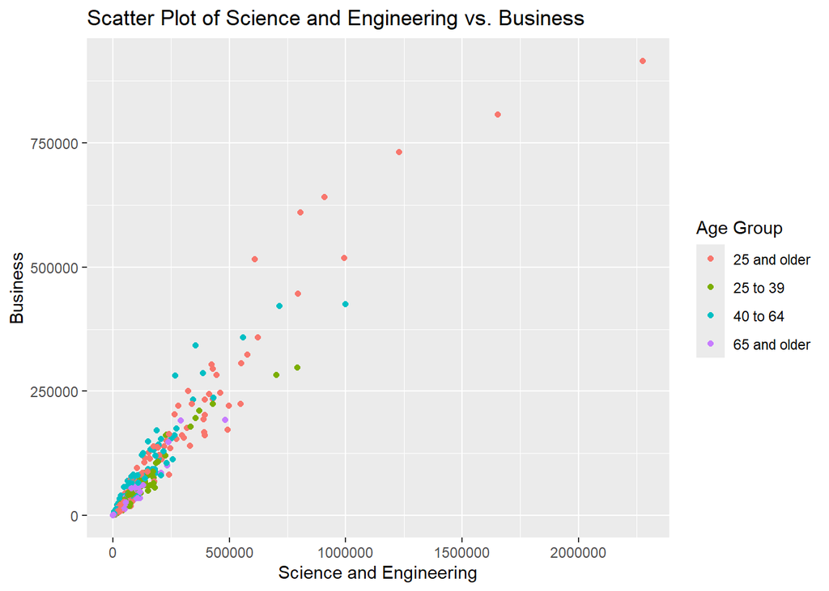

```r
ggplot(data, aes(x = Science.and.Engineering, y = Business, color = Age.Group)) +
  geom_point() +  # Add points for each data point
  scale_color_discrete(name = "Age Group") +  # Custom color legend title
  labs(x = "Science and Engineering", y = "Business") +  # Labels for x and y axes
  ggtitle("Scatter Plot of Science and Engineering vs. Business")  # Title for the plot
```

# Assignment 2: (up to 3 minues)

Using above code as example, create a plot for a diamond carot vs its price and show its cut as color (or any other plot of your choice).

We are going to learn how to do these by doing some example tasks.